# Logistic Regression

### 가정 진단

```r
plot(fit0)
```

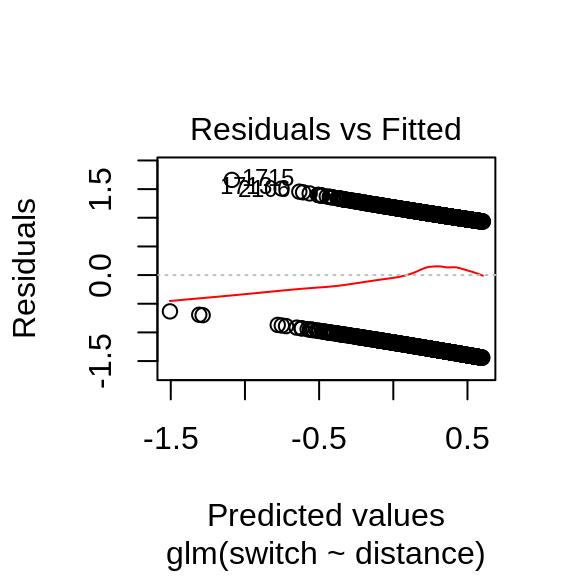

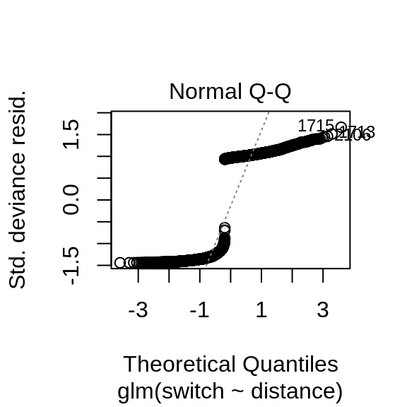

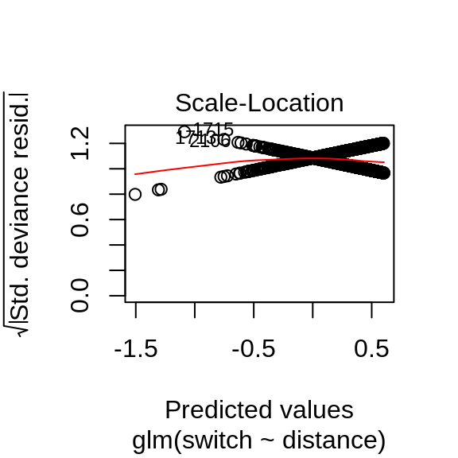

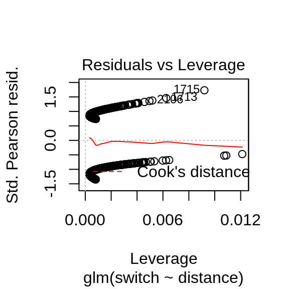

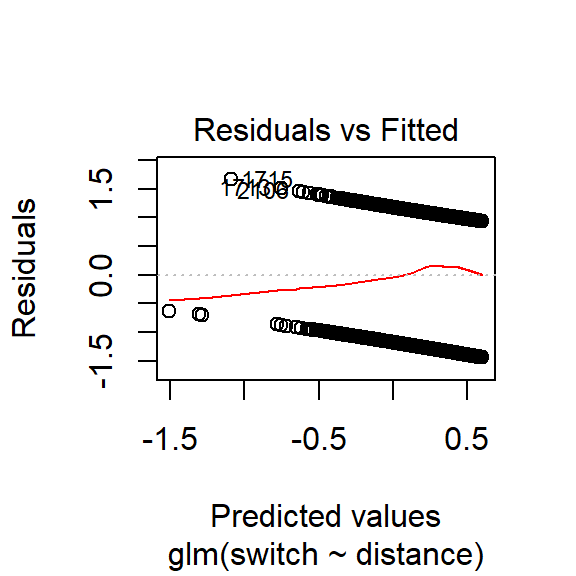

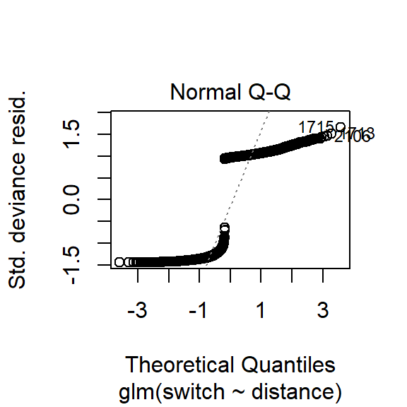

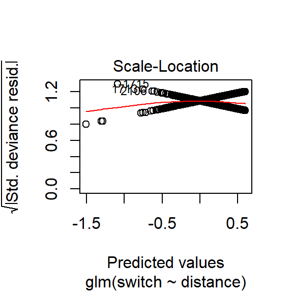

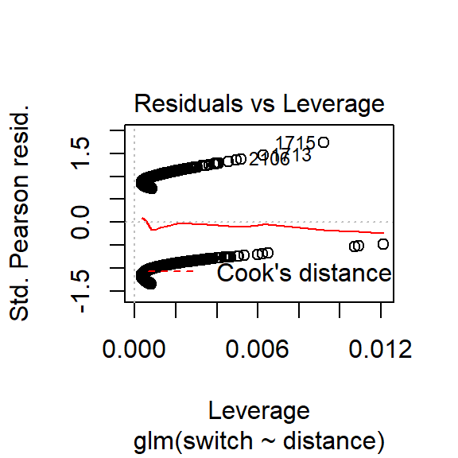

```r
binnedplot(fitted(fit0),
           residuals(fit0, type = "response"),
# type should be one of 'deviance', 'pearson', 'working', 'repsonse', 'partial'
           nclass = NULL,
           xlab = "Expected Values",
           ylab = "Average residual",
           main = "Binned residual plot",
           cex.pts = 0.8,
           col.pts = 1,
           col.int = "gray")
```

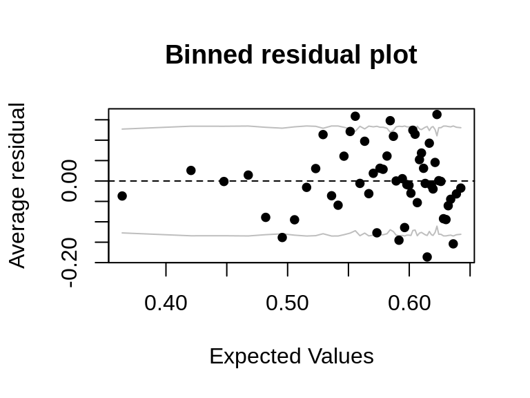

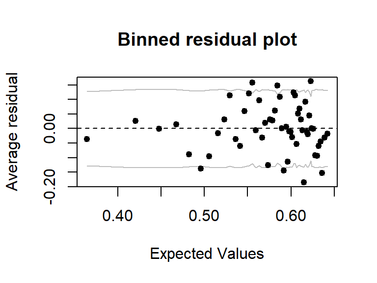

### 다중 로지스틱 회귀

```r
fitA <- glm(switch ~ association, family=binomial(link="logit"), data=Wells)
summary(fitA)
```

```
##
## Call:
## glm(formula = switch ~ association, family = binomial(link = "logit"),
##     data = Wells)
##
## Deviance Residuals:
##    Min      1Q  Median      3Q     Max
## -1.336  -1.272   1.027   1.027   1.086
##
## Coefficients:
##                Estimate Std. Error z value Pr(>|z|)
## (Intercept)     0.36546    0.04871   7.503 6.23e-14 ***
## associationyes -0.14690    0.07445  -1.973   0.0485 *
## ---
## Signif. codes:  0 '***' 0.001 '**' 0.01 '*' 0.05 '.' 0.1 ' ' 1
##
## (Dispersion parameter for binomial family taken to be 1)
##
##     Null deviance: 4118.1  on 3019  degrees of freedom
## Residual deviance: 4114.2  on 3018  degrees of freedom
## AIC: 4118.2
##
## Number of Fisher Scoring iterations: 4
```

```r
coef(fitA)
```

```
##    (Intercept) associationyes
##      0.3654598     -0.1468961
```

```r
confint(fitA)
```

```
##                     2.5 %        97.5 %
## (Intercept)     0.2702523  0.4612172518
## associationyes -0.2928178 -0.0009566043
```

```r
eff <- effect("association", fitA)
plot(eff) # type = "rescale", "response", "link"
```

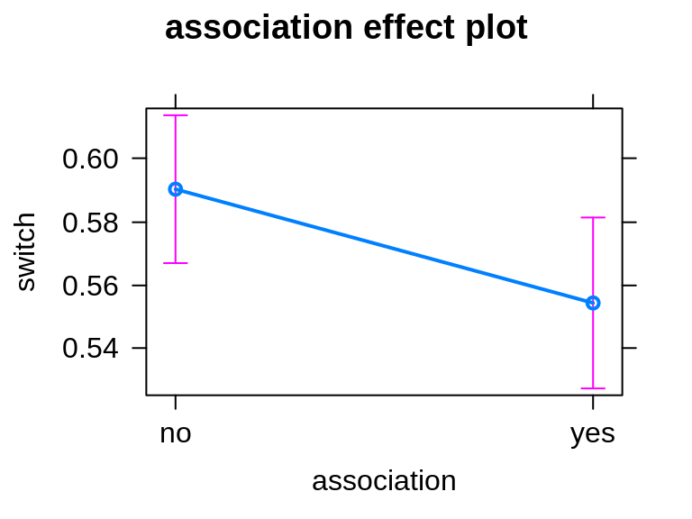

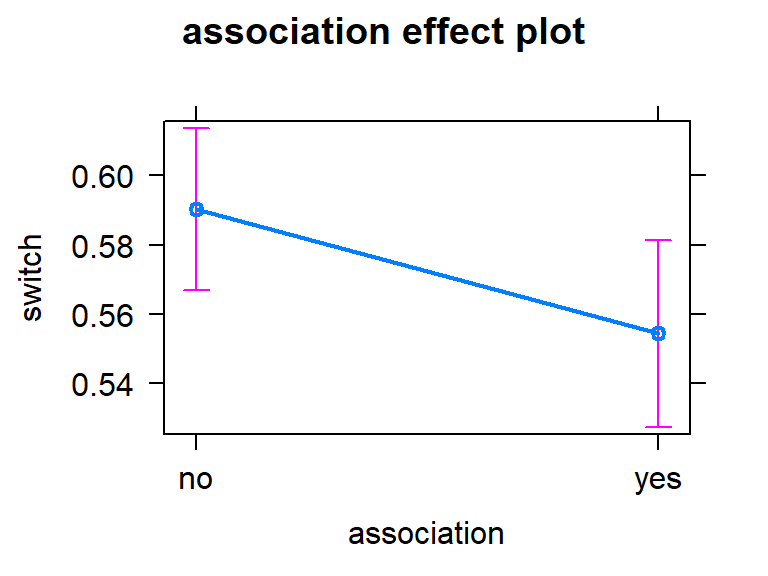

```r
fitB <- glm(switch ~ distance + association, family=binomial(link="logit"),
            data=Wells)
summary(fitB)
```

```
##
## Call:
## glm(formula = switch ~ distance + association, family = binomial(link = "logit"),
##     data = Wells)
##
## Deviance Residuals:
##    Min      1Q  Median      3Q     Max
## -1.468  -1.302   0.954   1.031   1.633
##
## Coefficients:
##                  Estimate Std. Error z value Pr(>|z|)
## (Intercept)     0.6705628  0.0685726   9.779  < 2e-16 ***
## distance       -0.0062307  0.0009744  -6.395 1.61e-10 ***
## associationyes -0.1504371  0.0749725  -2.007   0.0448 *
## ---
## Signif. codes:  0 '***' 0.001 '**' 0.01 '*' 0.05 '.' 0.1 ' ' 1
##
## (Dispersion parameter for binomial family taken to be 1)
##
##     Null deviance: 4118.1  on 3019  degrees of freedom
## Residual deviance: 4072.2  on 3017  degrees of freedom
## AIC: 4078.2
##
## Number of Fisher Scoring iterations: 4
```

```r
coef(fitB)
```

```
##    (Intercept)       distance associationyes
##     0.67056275    -0.00623066    -0.15043709
```

```r
confint(fitB)
```

```
##                       2.5 %       97.5 %
## (Intercept)     0.536730559  0.805588550
## distance       -0.008152661 -0.004331308
## associationyes -0.297396499 -0.003471271
```

```r
eff <- allEffects(fitB)
plot(eff, type='response') # type = "rescale", "response", "link"
```

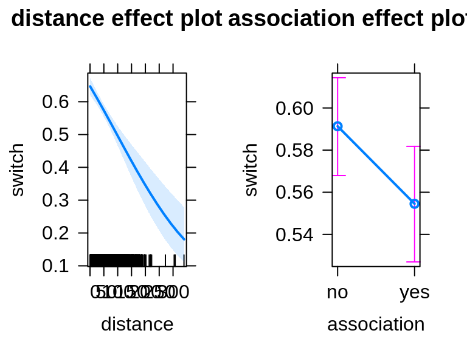

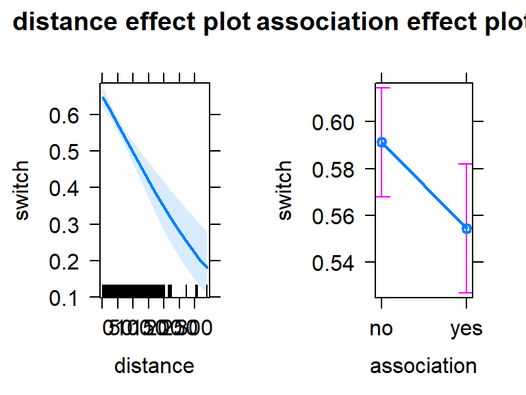

```r
#eff <- effect("distance", fitB)
#plot(eff, type='response') # type = "rescale", "response", "link"

fitC <- glm(switch ~ distance * association, family=binomial(link="logit"),
            data=Wells)
summary(fitC)
```

```
##
## Call:
## glm(formula = switch ~ distance * association, family = binomial(link = "logit"),
##     data = Wells)
##
## Deviance Residuals:
##     Min       1Q   Median       3Q      Max
## -1.4820  -1.2986   0.9467   1.0369   1.6972
##
## Coefficients:
##                          Estimate Std. Error z value Pr(>|z|)
## (Intercept)              0.702121   0.079837   8.794  < 2e-16 ***
## distance                -0.006873   0.001280  -5.368 7.98e-08 ***
## associationyes          -0.225434   0.121969  -1.848   0.0646 .
## distance:associationyes  0.001539   0.001975   0.780   0.4357
## ---
## Signif. codes:  0 '***' 0.001 '**' 0.01 '*' 0.05 '.' 0.1 ' ' 1
##
## (Dispersion parameter for binomial family taken to be 1)
##
##     Null deviance: 4118.1  on 3019  degrees of freedom
## Residual deviance: 4071.6  on 3016  degrees of freedom
## AIC: 4079.6
##
## Number of Fisher Scoring iterations: 4
```

```r
coef(fitC)
```

```
##             (Intercept)                distance          associationyes
##             0.702120847            -0.006872581            -0.225433875
## distance:associationyes
##             0.001539279
```

```r
confint(fitC)
```

```
##                                2.5 %       97.5 %
## (Intercept)              0.546548125  0.859611953
## distance                -0.009406141 -0.004382395
## associationyes          -0.464407605  0.013819823
## distance:associationyes -0.002337748  0.005407124
```

```r
eff <- allEffects(fitC)
plot(eff, type='response') # type = "rescale", "response", "link"
```

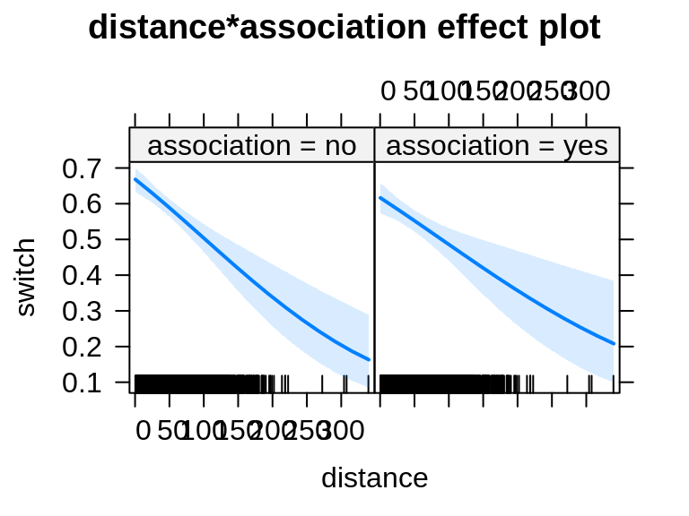

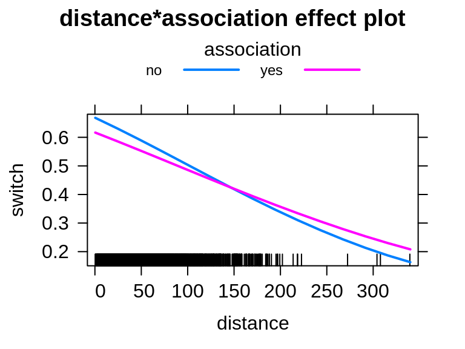

```r
eff2 <- effect("distance*association", fitC)
#plot(eff2, type='response')
plot(eff2, type='response', multiline=TRUE)
```

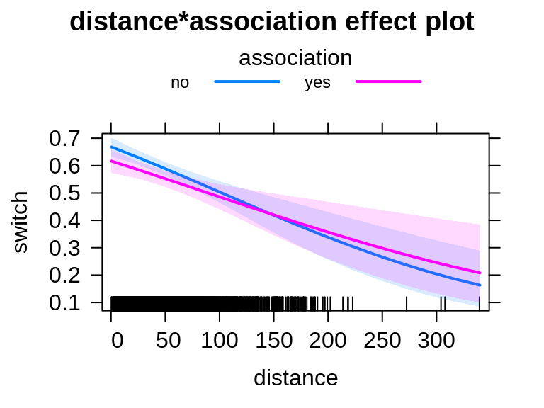

```r
plot(eff2, type='response', multiline=TRUE, confint=list(style='bands'))
```

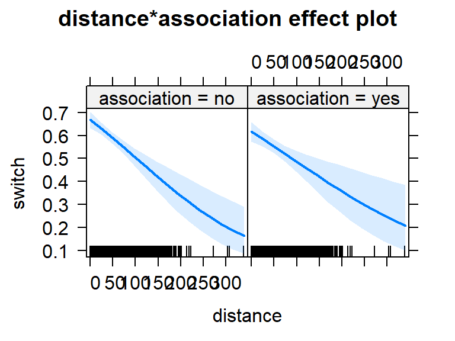

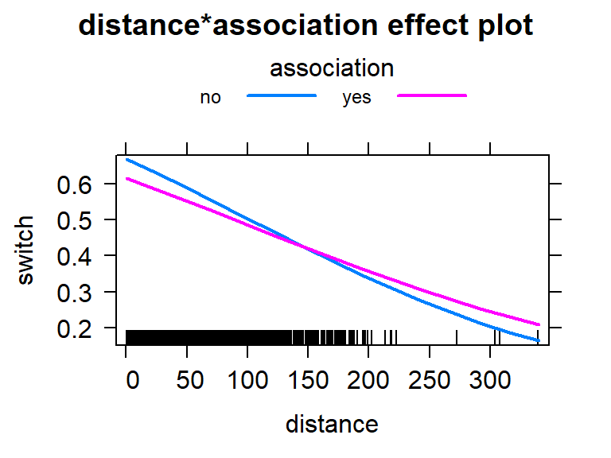

```r
eff2 <- effect("distance*association", fitC)
#plot(eff2, type='response')
plot(eff2, type='response', multiline=TRUE)
```

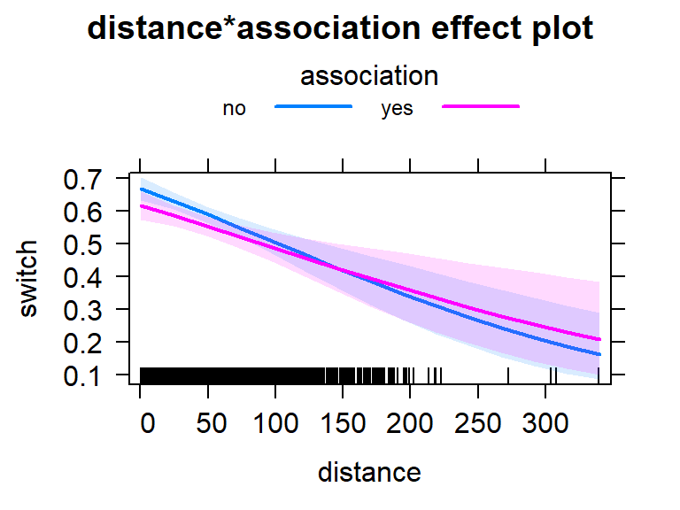

```r
plot(eff2, type='response', multiline=TRUE, confint=list(style='bands'))
```

### 예 : `GermanCredit` 데이터

#### 단순 로지스틱 회귀

```r
data('GermanCredit', package='caret')
fit0 <- glm(Class ~ Age, data=GermanCredit, family=binomial)
library(arm)
binnedplot(fitted(fit0),
           residuals(fit0, type = "response"),
# type should be one of 'deviance', 'pearson', 'working', 'repsonse', 'partial'
           nclass = NULL,
           xlab = "Expected Values",
           ylab = "Average residual",
           main = "Binned residual plot",
           cex.pts = 0.8,
           col.pts = 1,
           col.int = "gray")
```

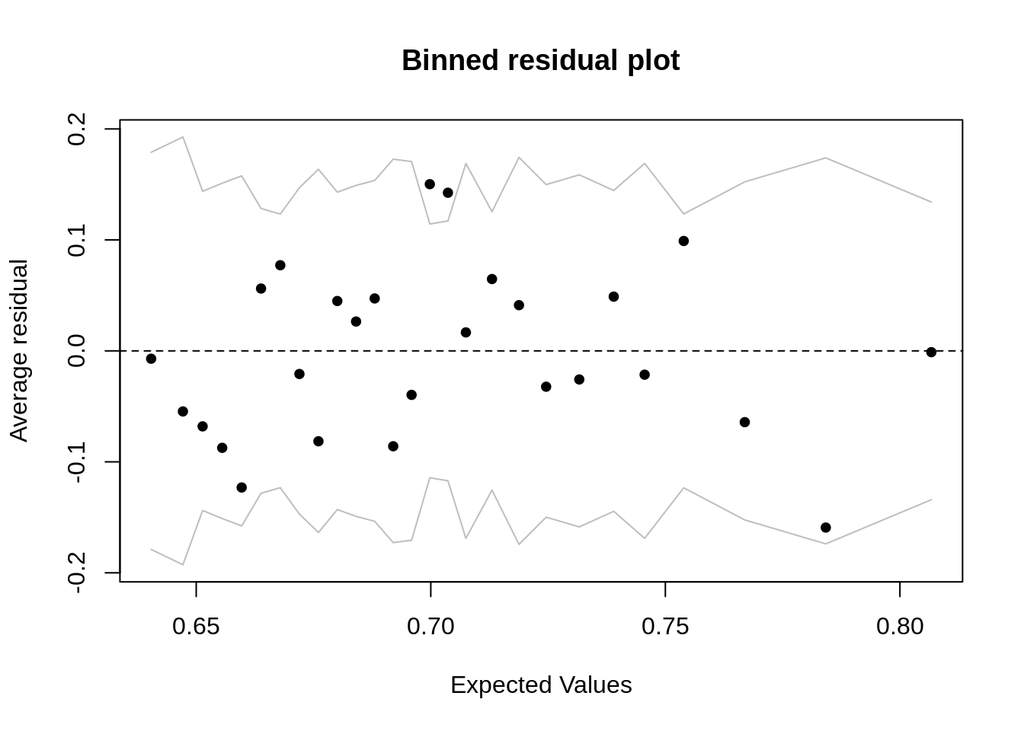

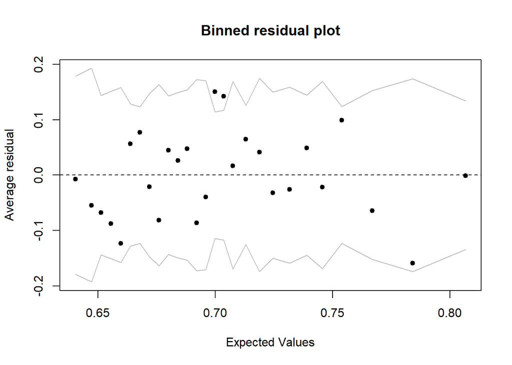

```r
summary(fit0)
```

```
##
## Call:
## glm(formula = Class ~ Age, family = binomial, data = GermanCredit)
##
## Deviance Residuals:
##     Min       1Q   Median       3Q      Max
## -1.8736  -1.4600   0.8063   0.8781   0.9540
##
## Coefficients:
##             Estimate Std. Error z value Pr(>|z|)
## (Intercept) 0.200919   0.232853   0.863  0.38822
## Age         0.018440   0.006434   2.866  0.00416 **
## ---
## Signif. codes:  0 '***' 0.001 '**' 0.01 '*' 0.05 '.' 0.1 ' ' 1
##
## (Dispersion parameter for binomial family taken to be 1)
##
##     Null deviance: 1221.7  on 999  degrees of freedom
## Residual deviance: 1213.1  on 998  degrees of freedom
## AIC: 1217.1
##
## Number of Fisher Scoring iterations: 4
```

```r
#plot(allEffects(fit0), type='rescale')
plot(allEffects(fit0), type='response')
```

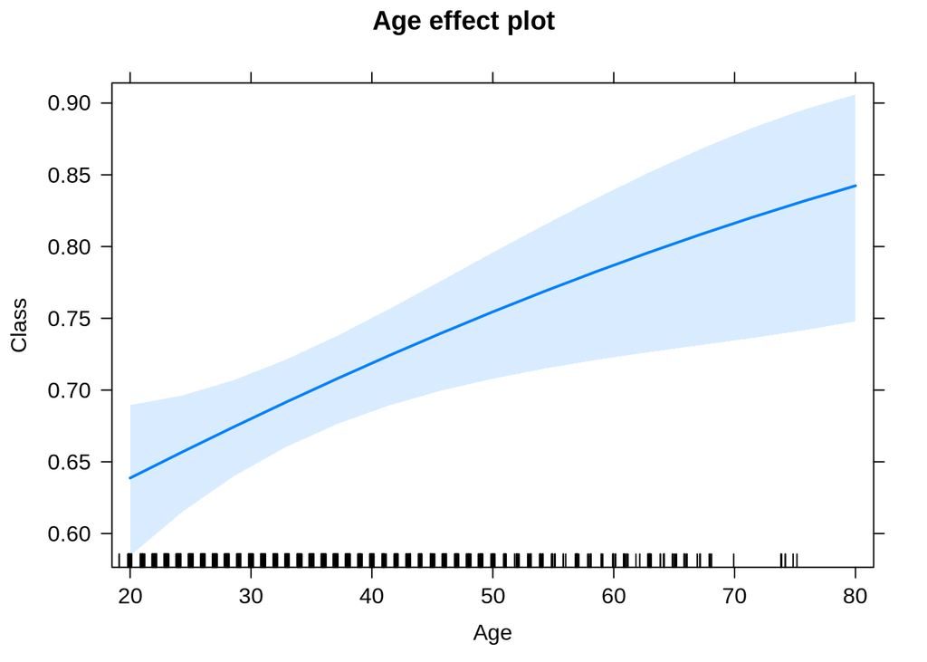

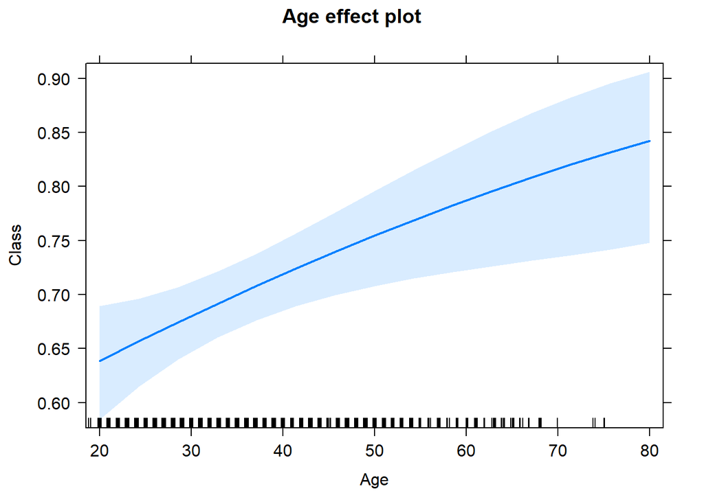

```r
#plot(allEffects(fit0), type='link')

#plot(effect('Age', fit0),  type='rescale')
#plot(effect('Age', fit0),  type='response')
#plot(effect('Age', fit0),  type='link')
```

#### 다중 로지스틱 회귀

```r
fit1 <- glm(Class ~ Age + Housing.Rent, data=GermanCredit, family=binomial)
library(arm)
binnedplot(fitted(fit1),
           residuals(fit1, type = "response"),
# type should be one of 'deviance', 'pearson', 'working', 'repsonse', 'partial'
           nclass = NULL,
           xlab = "Expected Values",
           ylab = "Average residual",
           main = "Binned residual plot",
           cex.pts = 0.8,
           col.pts = 1,
           col.int = "gray")
```

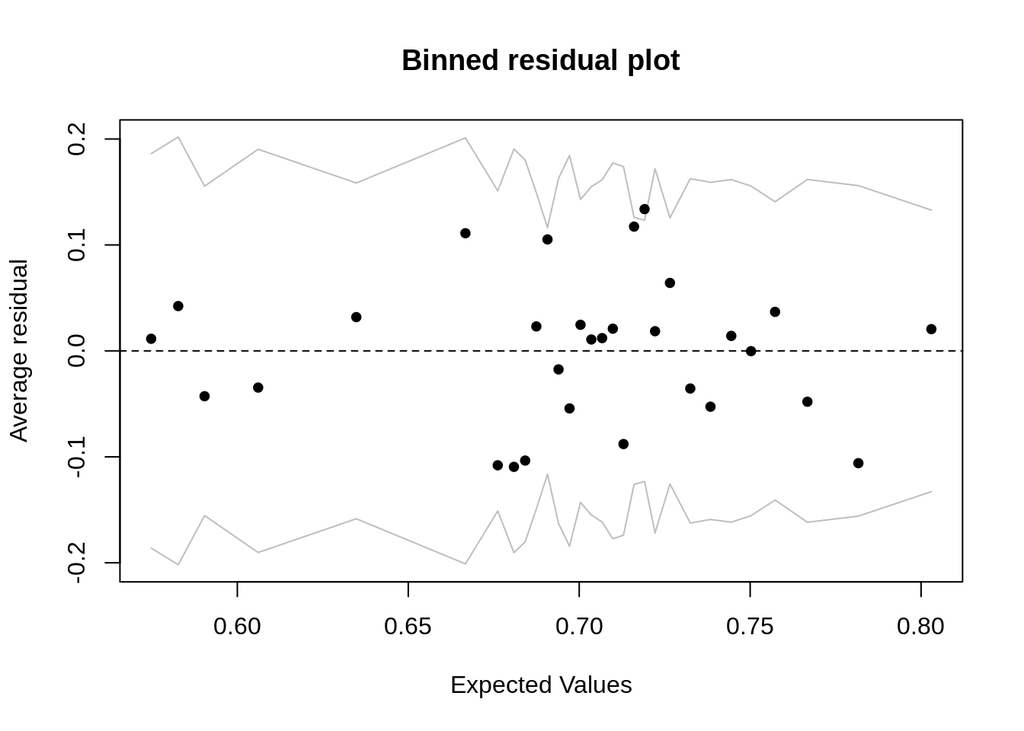

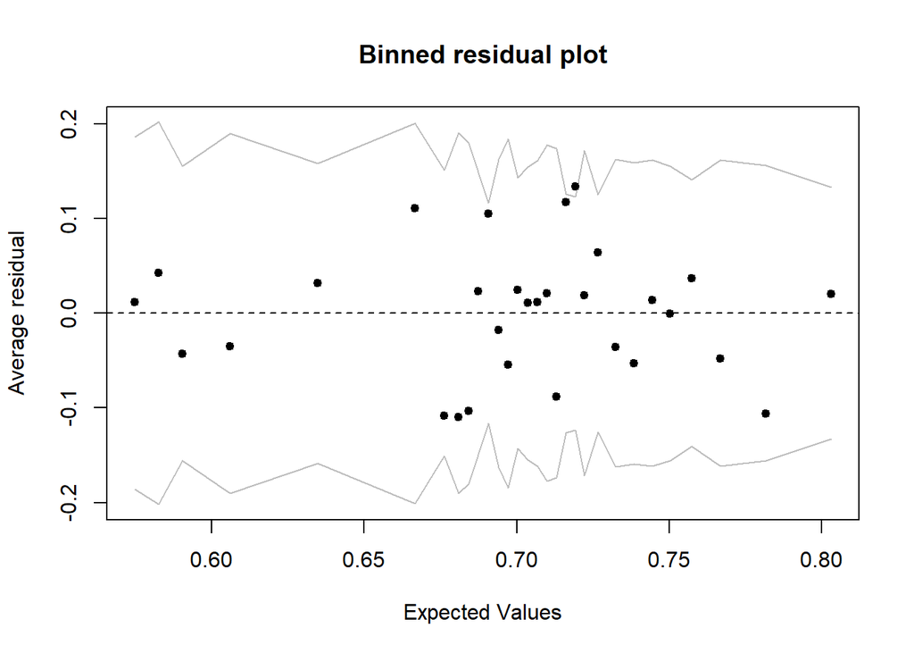

```r
summary(fit1)
```

```
##
## Call:
## glm(formula = Class ~ Age + Housing.Rent, family = binomial,
##     data = GermanCredit)
##
## Deviance Residuals:
##     Min       1Q   Median       3Q      Max
## -1.8522  -1.3759   0.7964   0.8548   1.0638
##
## Coefficients:
##               Estimate Std. Error z value Pr(>|z|)
## (Intercept)   0.393616   0.247041   1.593   0.1111
## Age           0.015180   0.006548   2.318   0.0204 *
## Housing.Rent -0.408844   0.176402  -2.318   0.0205 *
## ---
## Signif. codes:  0 '***' 0.001 '**' 0.01 '*' 0.05 '.' 0.1 ' ' 1
##
## (Dispersion parameter for binomial family taken to be 1)
##
##     Null deviance: 1221.7  on 999  degrees of freedom
## Residual deviance: 1207.9  on 997  degrees of freedom
## AIC: 1213.9
##
## Number of Fisher Scoring iterations: 4
```

```r
#plot(allEffects(fit1), type='rescale')
plot(allEffects(fit1), type='response')
```

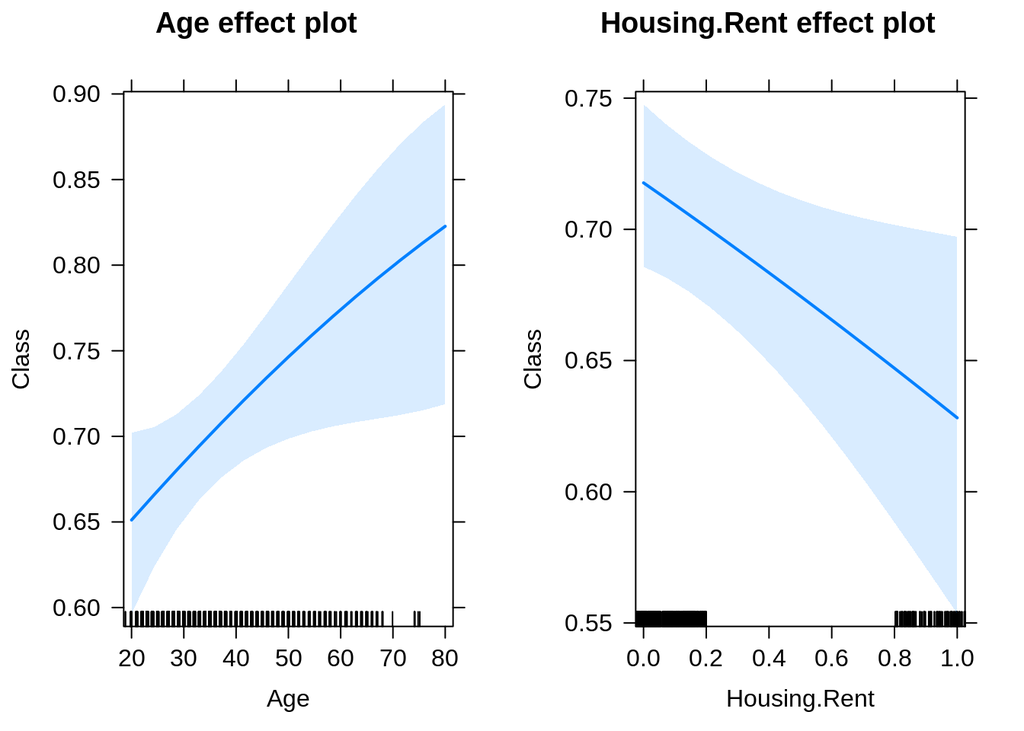

```
## NOTE: Age:Housing.Rent does not appear in the model
```

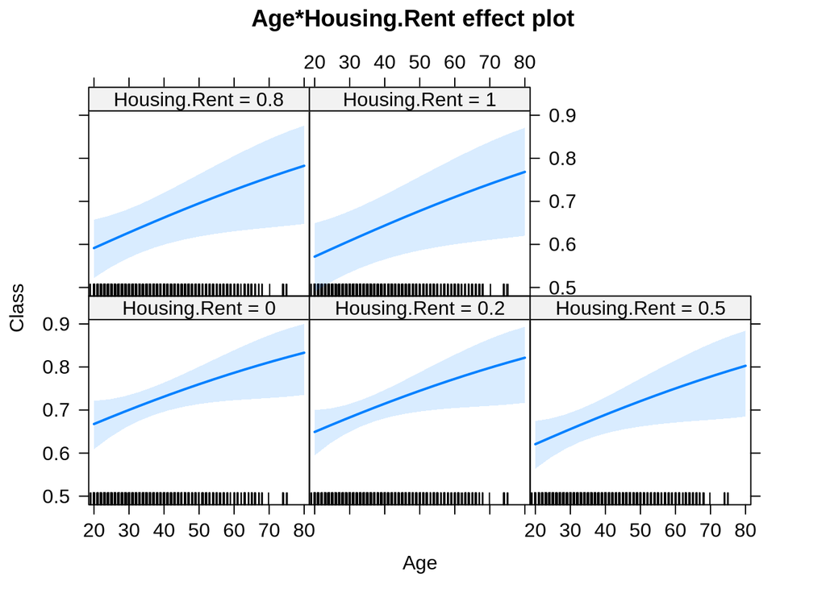

```r
#plot(allEffects(fit1), type='link')

plot(effect('Age*Housing.Rent', fit1),  type='response')
```

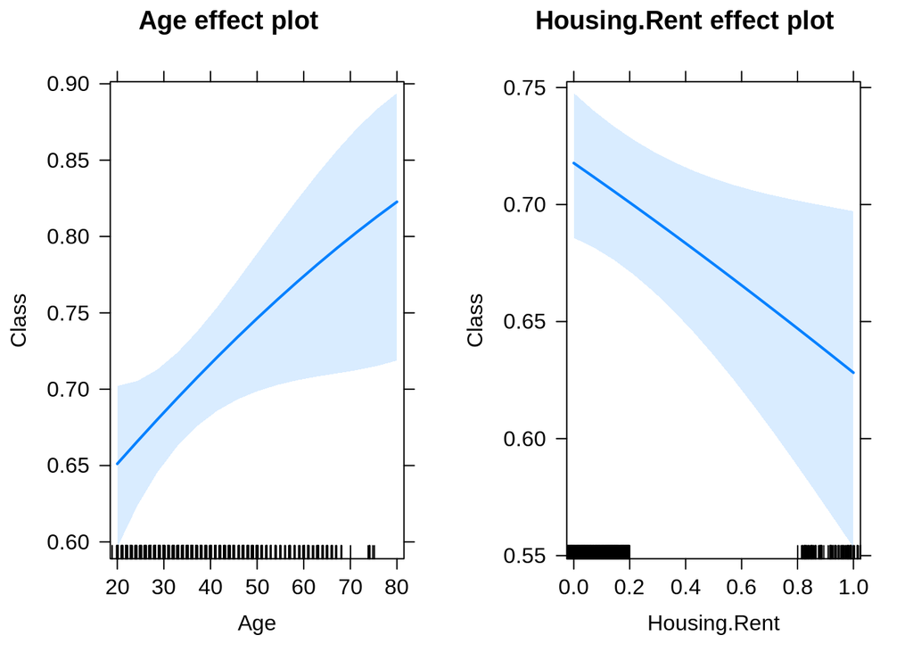

```r
plot(allEffects(fit1), type='response', multiline=TRUE, confint=list(style='bands'))
```

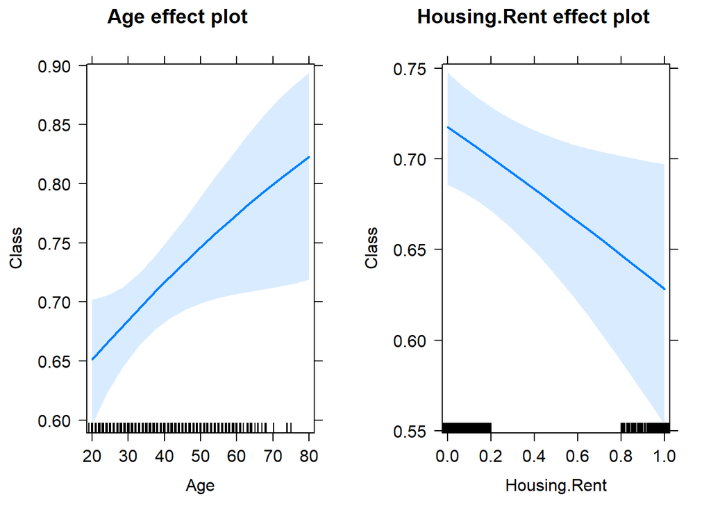

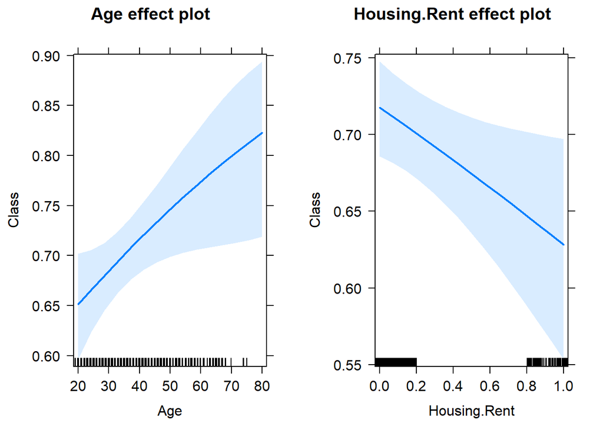

```r
#plot(allEffects(fit1), type='link')

#plot(effects('Age*Housing.Rent', fit1),  type='response')
plot(allEffects(fit1), type='response', multiline=TRUE, confint=list(style='bands'))
```

#### 상호작용을 포함한 다중 로지스틱 회귀

```r
fit2 <- glm(Class ~ Age * Housing.Rent, data=GermanCredit, family=binomial)
library(arm)
binnedplot(fitted(fit2),
           residuals(fit2, type = "response"),
# type should be one of 'deviance', 'pearson', 'working', 'repsonse', 'partial'
           nclass = NULL,
           xlab = "Expected Values",
           ylab = "Average residual",
           main = "Binned residual plot",
           cex.pts = 0.8,
           col.pts = 1,
           col.int = "gray")
```

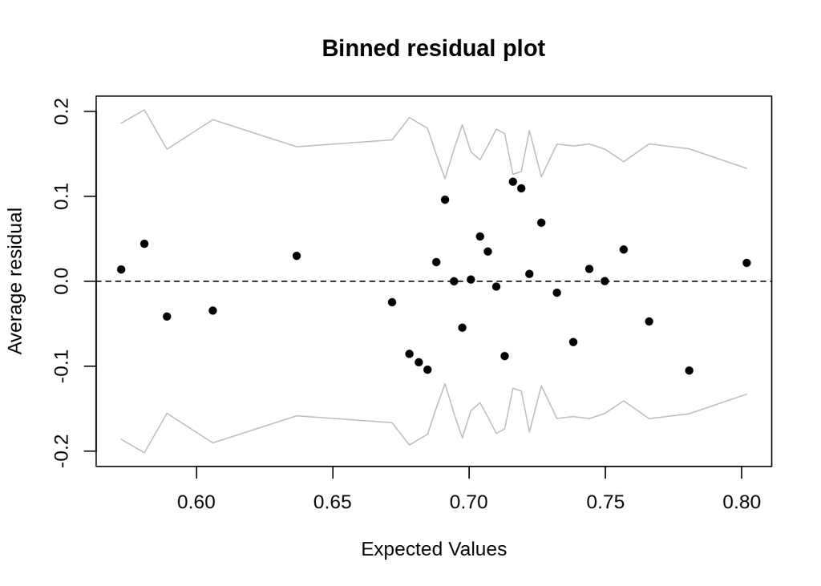

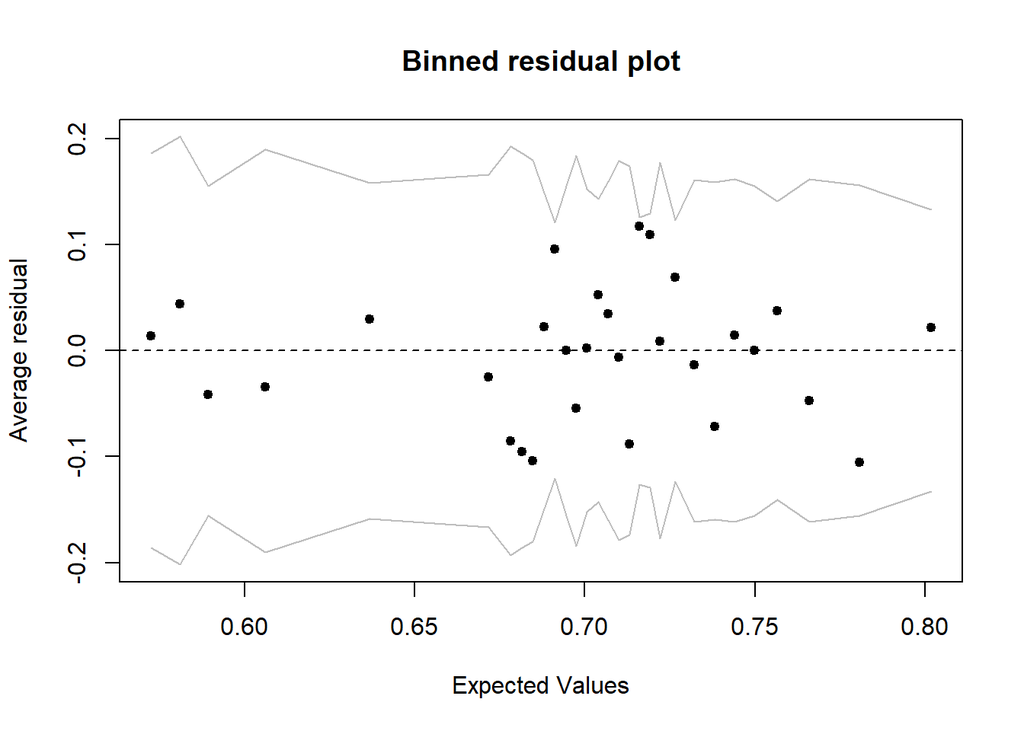

```r
summary(fit2)
```

```
##
## Call:
## glm(formula = Class ~ Age * Housing.Rent, family = binomial,
##     data = GermanCredit)
##
## Deviance Residuals:
##     Min       1Q   Median       3Q      Max
## -1.8482  -1.3764   0.7967   0.8542   1.0688
##
## Coefficients:
##                   Estimate Std. Error z value Pr(>|z|)
## (Intercept)       0.401973   0.269379   1.492   0.1356
## Age               0.014947   0.007200   2.076   0.0379 *
## Housing.Rent     -0.450460   0.564032  -0.799   0.4245
## Age:Housing.Rent  0.001344   0.017310   0.078   0.9381
## ---
## Signif. codes:  0 '***' 0.001 '**' 0.01 '*' 0.05 '.' 0.1 ' ' 1
##
## (Dispersion parameter for binomial family taken to be 1)
##
##     Null deviance: 1221.7  on 999  degrees of freedom
## Residual deviance: 1207.9  on 996  degrees of freedom
## AIC: 1215.9
##
## Number of Fisher Scoring iterations: 4
```

```r
#plot(allEffects(fit1), type='rescale')
plot(allEffects(fit2), type='response')
```

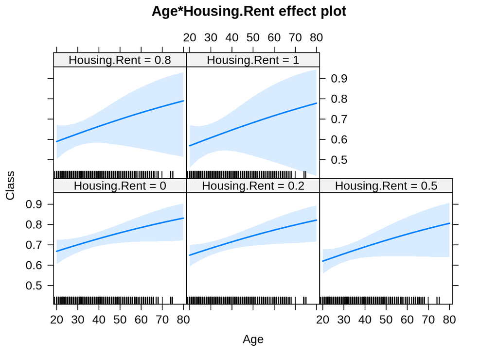

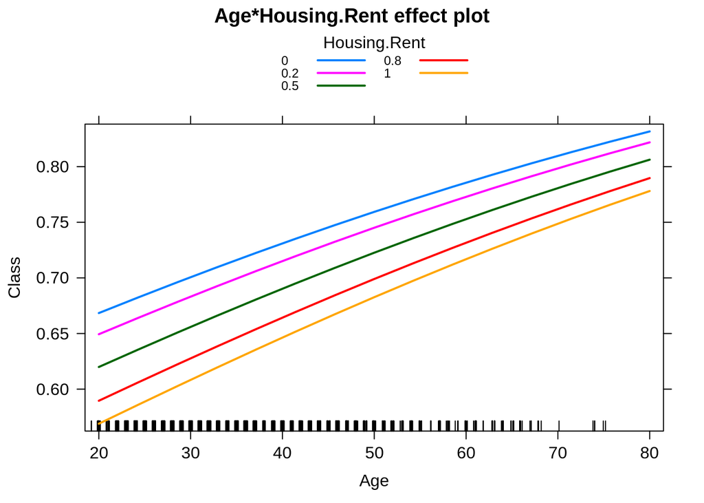

```r
plot(allEffects(fit2), type='response', multiline=TRUE)
```

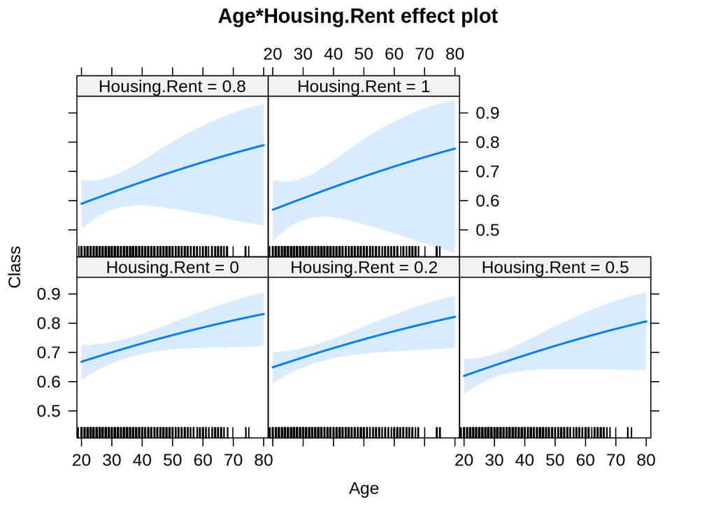

```r
#plot(allEffects(fit1), type='link')

plot(effect('Age*Housing.Rent', fit2),  type='response')
```

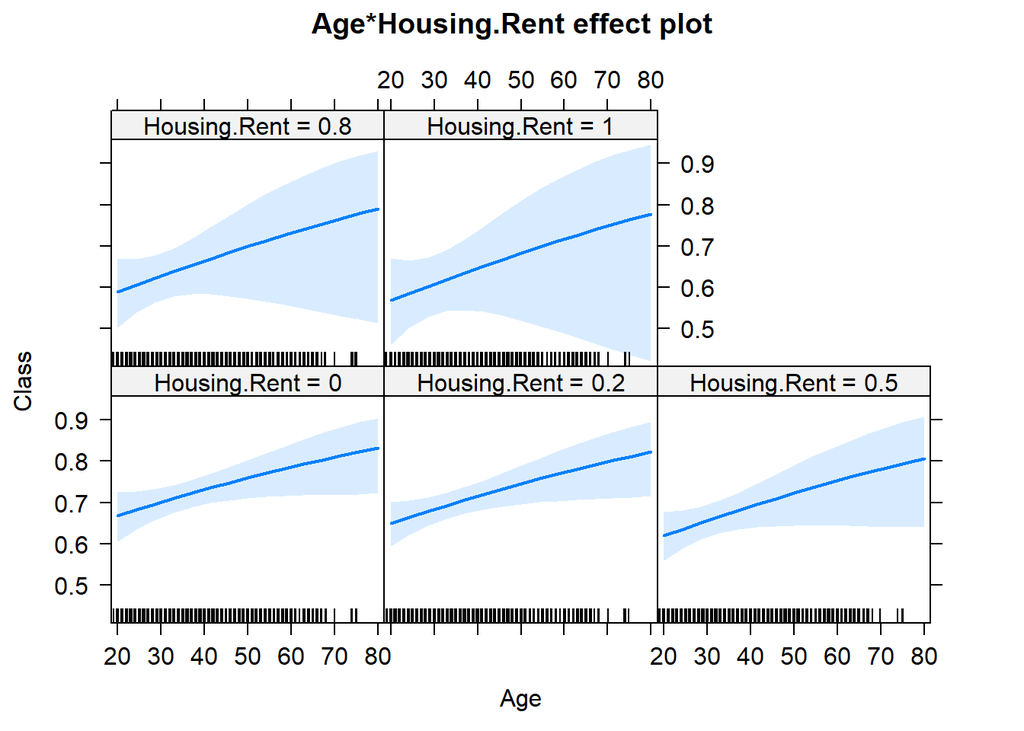

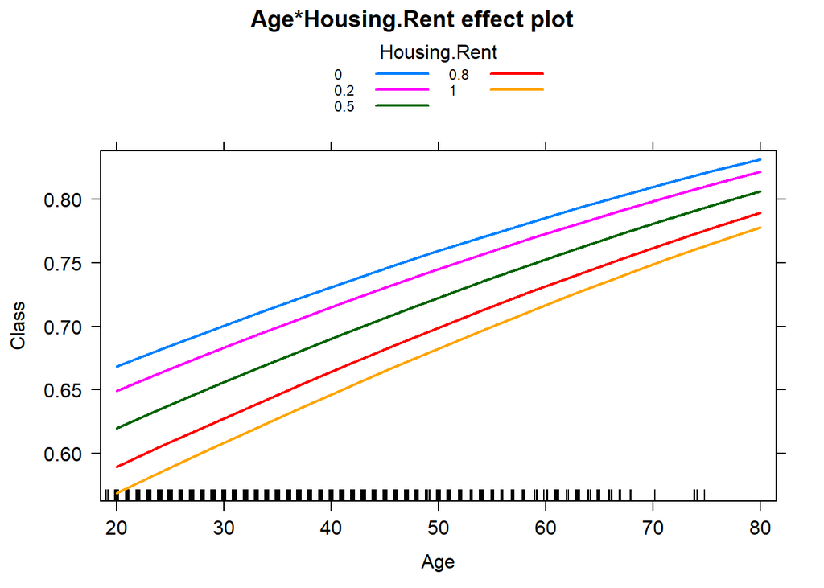

```r
plot(allEffects(fit2), type='response', multiline=TRUE)
```

```r
#plot(allEffects(fit1), type='link')

#plot(effects('Age*Housing.Rent', fit2),  type='response')
```

### 발생 가능한 문제들

- 공선성
- 분리(seperation) 문제
- 결과변수가 지나치게 불균형인 경우 : 예) 실제 양성이 99%라면 무조건 양성으로 탐지할 때, 정확률은 99%이다.

### 모형평가

- TP(true positive; 진양성), FP(false positive; 위양성) = false alarm(오탐)
- TN(true negative; 진음성), FN(false negative; 위음성)
- 분모에 전체 분류가 들어간 평가방법
  - 정확도(accuracy) : 전체 분류에서 제대로 된 분류의 비율. (TP+TN)/(TP+TN+FP+FN) = (TP+TN)/(P+N).
  - 오류율(error rate) : 전체 분류에서 잘못된 분류의 비율.
- 분모에 실제 양성 또는 음성이 들어간 평가방법
  - 민감도(sensitivity) 또는 재현율(recall) : 실제 양성 중 양성으로 분류된 비율. TP/P.
  - 특이도(specificity) : 실제 음성 중 정확하게 음성으로 분류된 비율. TN/N.
- 분모에 탐지된 양성 또는 음성이 들어간 평가방법
  - 정밀도(precision) 또는 양성예측도(Positive Predictive Value) : 양성 탐지 중 실제 양성의 비율. TP/(TP+FP).
  - 음성예측도(Negative Predictive Value) : 음성 탐지 중 실제 음성의 비율. TN/(TN+FN).

```r
fit0 <- glm(switch ~ distance, family=binomial(link="logit"),
            data=Wells)
pred <- predict(fit0, type='link') > 0
pred <- ifelse(pred == TRUE, "yes", "no")
pred <- factor(pred, levels = c('no', 'yes'))
table(pred, Wells$switch)
```

```
##
## pred    no  yes
##   no   194  133
##   yes 1089 1604
```

```r
library(caret)
confusionMatrix(pred, Wells$switch, positive='yes')
```

```
## Confusion Matrix and Statistics
##
##           Reference
## Prediction   no  yes
##        no   194  133
##        yes 1089 1604
##
##                Accuracy : 0.5954
##                  95% CI : (0.5776, 0.6129)
##     No Information Rate : 0.5752
##     P-Value [Acc > NIR] : 0.01284
##
##                   Kappa : 0.0827
##  Mcnemar's Test P-Value : < 2e-16
##
##             Sensitivity : 0.9234
##             Specificity : 0.1512
##          Pos Pred Value : 0.5956
##          Neg Pred Value : 0.5933
##              Prevalence : 0.5752
##          Detection Rate : 0.5311
##    Detection Prevalence : 0.8917
##       Balanced Accuracy : 0.5373
##
##        'Positive' Class : yes
##
```